# LCMS wrangling

Date initiated: 2019-05-08 Date last compiled: 2019-06-18

#TODO:

- Fix problem in `2018 image processing.Rmd` that makes the `sample` and `plant_num` columns not uniform. `sample` should be “Q12”, `plant_num` should be “12”.

```r
library(tidyverse)
library(here)
library(janitor)
library(chemhelper) #might not need?
library(readxl)
# library(tidyselect)
```

# Import Data

This is a very very ugly spreadsheet. The sample names and data are not really easily combined. I think I’ll read them in separately and combine later?

## LCMS data

```r
lcms_data.raw <- read_excel(here("data", "raw", "Tea_LCMS_Report_050719.xlsx"),
                        range = "C16:GF31")
```

```
* Conc -> Conc...11
* Flags -> Flags...12
* Conc -> Conc...13
* Flags -> Flags...14
* Conc -> Conc...15
* … and 171 more problems
```

```r
lcms_data <-
  lcms_data.raw %>%
  slice(-1) %>% #remove blank row
  clean_names() %>%
  select(-(2:10)) #get rid of compound metadata
```

Now capture sample names

```r
sample_names <- read_excel(here("data", "raw", "Tea_LCMS_Report_050719.xlsx"),
    range = "M4:GF5")
```

```
* blank -> blank...1
* `` -> ...2
* `` -> ...4
* `` -> ...6
* `` -> ...8
* … and 100 more problems
```

```r
colnames(lcms_data) <- c("compound", colnames(sample_names))
```

get rid of flags columns and gather

```r
lcms_tidy <-
  lcms_data %>%
  select(-starts_with("...")) %>% #flags columns, not important
  gather(-compound, key = "sample", value = "conc") %>%
  mutate(conc = as.numeric(conc)) %>%  #NAs are non-detects. need to deal with later.
  filter(!str_detect(sample, "blank"), !str_detect(sample, "Tea_Std")) #remove blanks and standards
```

```
NAs introduced by coercion
```

# Create columns for cultivar and plant number

```r
lcms_tidy <-
  lcms_tidy %>%
  mutate(cultivar = str_extract(sample, "^\\D")) %>%
  mutate(plant_num = str_extract(sample, "\\d+")) %>%
  select(compound, sample, cultivar, plant_num, conc)
```

# Deal with duplicates

For Q14–Q20 the samples were run twice. Josh ran out of nitrogen for a few weeks and when he got more, he ran diluted samples that had been kept at -4º as well as new dilutions from samples that had been kept at -80º. He said the -80 storage (Q##_2) look more similar to the other samples and I should probably use those. It looks like there was a storage effect for theanine, caffeine, and ECG (and maybe EGCG)

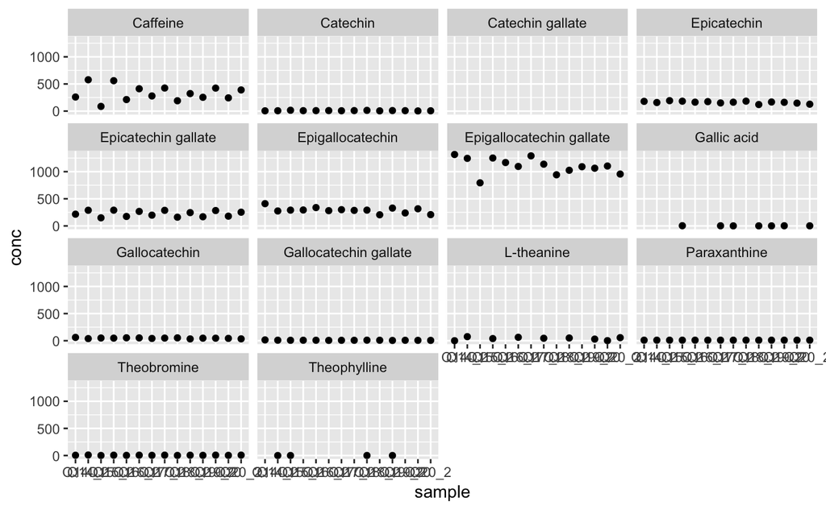

```r
lcms_tidy %>%
  filter(sample %in% c("Q14", "Q14_2", "Q15", "Q15_2", "Q16", "Q16_2", "Q17", "Q17_2", "Q18", "Q18_2", "Q19", "Q19_2", "Q20", "Q20_2")) %>%
ggplot(aes(x = sample, y = conc)) +
  geom_point() +
  facet_wrap(~compound)
```

```r
lcms_tidy <-
  lcms_tidy %>%
  filter(!sample %in% c(paste0("Q", 14:20))) %>%
  mutate(sample = str_remove(sample, "_\\d"))
```

# Divide by leaf powder ammount

Josh’s data is in µg/mL and he said he accounted for the 10.1 dillution. We used about 20 mg for 1 mL for the extraction. So, to get µg/mg should just have to divide by the sample amount (about 20mg).

To get µg/mg tea leaf

```r
sample_ammount_2017 <-
  read_csv(here("data", "raw", "2017QData - Sheet1.csv")) %>%
  clean_names() %>%
  select(sample, mg_tea)
sample_ammount_2018 <-
  read_csv(here('data', 'raw', '2018 total polyphenols.csv')) %>%
  clean_names() %>%
  select(sample, mg_tea)
sample_ammount <- bind_rows(sample_ammount_2017, sample_ammount_2018)
```

```r
lcms_tidy <-
  full_join(lcms_tidy, sample_ammount) %>%
  mutate(conc_ug_mg = conc/mg_tea)
```

# Add in treatment and leaf damage data

| compound | sample | cultivar | plant_num | conc | mg_tea | conc_ug_mg | mean_leaf_area_px | mean_percent_damage | n_leaves | twister_damage | density_treatment | density_start | density_end |
| --- | --- | --- | --- | --- | --- | --- | --- | --- | --- | --- | --- | --- | --- |
| L-theanine | Q20 | Q | 20 | 56.4810 | 21.1 | 2.676824645 | 168116.8 | 1.36435254 | 13 | 0.593847672 | 0.00 | 0.0000000 | 0.00000000 |
| Gallic acid | Q20 | Q | 20 | 1.6209 | 21.1 | 0.076819905 | 168116.8 | 1.36435254 | 13 | 0.593847672 | 0.00 | 0.0000000 | 0.00000000 |
| Gallocatechin | Q20 | Q | 20 | 34.4180 | 21.1 | 1.631184834 | 168116.8 | 1.36435254 | 13 | 0.593847672 | 0.00 | 0.0000000 | 0.00000000 |
| Theobromine | Q20 | Q | 20 | 7.5533 | 21.1 | 0.357976303 | 168116.8 | 1.36435254 | 13 | 0.593847672 | 0.00 | 0.0000000 | 0.00000000 |
| Paraxanthine | Q20 | Q | 20 | 10.0990 | 21.1 | 0.478625592 | 168116.8 | 1.36435254 | 13 | 0.593847672 | 0.00 | 0.0000000 | 0.00000000 |
| Theophylline | Q20 | Q | 20 | NA | 21.1 | NA | 168116.8 | 1.36435254 | 13 | 0.593847672 | 0.00 | 0.0000000 | 0.00000000 |
| Catechin | Q20 | Q | 20 | 5.7800 | 21.1 | 0.273933649 | 168116.8 | 1.36435254 | 13 | 0.593847672 | 0.00 | 0.0000000 | 0.00000000 |
| Epigallocatechin | Q20 | Q | 20 | 207.8400 | 21.1 | 9.850236967 | 168116.8 | 1.36435254 | 13 | 0.593847672 | 0.00 | 0.0000000 | 0.00000000 |
| Caffeine | Q20 | Q | 20 | 390.1300 | 21.1 | 18.489573460 | 168116.8 | 1.36435254 | 13 | 0.593847672 | 0.00 | 0.0000000 | 0.00000000 |
| Epigallocatechin gallate | Q20 | Q | 20 | 955.2900 | 21.1 | 45.274407583 | 168116.8 | 1.36435254 | 13 | 0.593847672 | 0.00 | 0.0000000 | 0.00000000 |

[output cut: 858 more lines]

Ok, now I need to do a few more things:

- deal with non-detects
  - could use 1/IS (paraxanthine), but I’m not sure that makes sense
  - could use 0
  - could use 1/small number. E.g. smallest concentration detected in whole dataset.
- separate 2017 and 2018 data
- Spread so each compound is a column to get wide data for stats

# Split 2017 and 2018

These should be analyzed separately since methods were different. That’s why I’m splitting them in the wrangling step.

| compound | sample | cultivar | plant_num | conc | mg_tea | conc_ug_mg | mean_leaf_area_px | mean_percent_damage | n_leaves | twister_damage | density_treatment | density_start | density_end |
| --- | --- | --- | --- | --- | --- | --- | --- | --- | --- | --- | --- | --- | --- |
| L-theanine | J24 | J | 24 | 100.0400 | 21.0 | 4.76380952 | 223639.9 | 0.13649669 | 44 | 0.015026296 | 1.00 | 0.9375000 | 0.18750000 |
| Gallic acid | J24 | J | 24 | NA | 21.0 | NA | 223639.9 | 0.13649669 | 44 | 0.015026296 | 1.00 | 0.9375000 | 0.18750000 |
| Gallocatechin | J24 | J | 24 | 79.4830 | 21.0 | 3.78490476 | 223639.9 | 0.13649669 | 44 | 0.015026296 | 1.00 | 0.9375000 | 0.18750000 |
| Theobromine | J24 | J | 24 | 24.4040 | 21.0 | 1.16209524 | 223639.9 | 0.13649669 | 44 | 0.015026296 | 1.00 | 0.9375000 | 0.18750000 |
| Paraxanthine | J24 | J | 24 | 10.0990 | 21.0 | 0.48090476 | 223639.9 | 0.13649669 | 44 | 0.015026296 | 1.00 | 0.9375000 | 0.18750000 |
| Theophylline | J24 | J | 24 | NA | 21.0 | NA | 223639.9 | 0.13649669 | 44 | 0.015026296 | 1.00 | 0.9375000 | 0.18750000 |
| Catechin | J24 | J | 24 | 13.9150 | 21.0 | 0.66261905 | 223639.9 | 0.13649669 | 44 | 0.015026296 | 1.00 | 0.9375000 | 0.18750000 |
| Epigallocatechin | J24 | J | 24 | 342.6500 | 21.0 | 16.31666667 | 223639.9 | 0.13649669 | 44 | 0.015026296 | 1.00 | 0.9375000 | 0.18750000 |
| Caffeine | J24 | J | 24 | 836.0000 | 21.0 | 39.80952381 | 223639.9 | 0.13649669 | 44 | 0.015026296 | 1.00 | 0.9375000 | 0.18750000 |
| Epigallocatechin gallate | J24 | J | 24 | 1446.4000 | 21.0 | 68.87619048 | 223639.9 | 0.13649669 | 44 | 0.015026296 | 1.00 | 0.9375000 | 0.18750000 |

[output cut: 592 more lines]

# Create wide versions

| sample | cultivar | plant_num | mean_leaf_area_px | mean_percent_damage | n_leaves | twister_damage | density_treatment | density_start | density_end | Caffeine | Catechin | Catechin gallate | Epicatechin | Epicatechin gallate | Epigallocatechin | Epigallocatechin gallate | Gallic acid | Gallocatechin | Gallocatechin gallate | L-theanine | Paraxanthine | Theobromine | Theophylline |
| --- | --- | --- | --- | --- | --- | --- | --- | --- | --- | --- | --- | --- | --- | --- | --- | --- | --- | --- | --- | --- | --- | --- | --- |
| Q20 | Q | 20 | 168116.8 | 1.3643525 | 13 | 0.5938477 | 0.0 | 0.000000 | 0.0000000 | 18.489573 | 0.2739336 | NA | 6.028910 | 11.978673 | 9.850237 | 45.27441 | 0.07681991 | 1.631185 | 0.3026398 | 2.67682464 | 0.4786256 | 0.35797630 | NA |
| Q19 | Q | 19 | 233326.6 | 1.7313143 | 16 | 4.2058406 | 1.0 | 1.000000 | 0.6875000 | 20.354808 | 0.3765577 | NA | 7.781731 | 13.618750 | 11.466827 | 51.12500 | 0.13409135 | 2.238990 | 0.3912933 | 1.42947115 | 0.4855288 | 0.35937500 | NA |
| Q18 | Q | 18 | 199352.7 | 2.1599323 | 15 | 1.7576880 | 2.0 | 2.000000 | 0.7333333 | 15.304739 | 0.2132370 | NA | 5.733649 | 11.623697 | 9.721327 | 48.59242 | 0.05179621 | 1.580664 | 0.4203791 | 2.38834123 | 0.4786256 | 0.25927962 | NA |
| Q17 | Q | 17 | 152969.4 | 5.0878993 | 10 | 8.5405229 | 1.0 | 1.000000 | 0.6818182 | 21.029208 | 0.4523069 | NA | 8.118812 | 14.203960 | 14.156931 | 56.31683 | 0.04060891 | 2.409109 | 0.3944455 | 2.25029703 | 0.4999505 | 0.36300495 | NA |
| Q16 | Q | 16 | 287036.1 | 1.3494827 | 14 | 5.7526918 | 0.0 | 0.000000 | 0.0000000 | 19.989320 | 0.4571311 | NA | 8.456311 | 12.963592 | 13.633495 | 53.19417 | NA | 2.512767 | 0.3029466 | 3.06485437 | 0.4902427 | 0.32961165 | NA |
| Q15 | Q | 15 | 405769.3 | 0.9521822 | 6 | 1.2968796 | 2.0 | 2.000000 | 0.6250000 | 27.880100 | 0.3889104 | NA | 9.085075 | 14.429353 | 14.602488 | 62.24876 | 0.17442786 | 2.375672 | 0.4436070 | 1.97213930 | 0.5024378 | 0.31430846 | NA |
| Q14 | Q | 14 | 239493.7 | 1.5724456 | 15 | 1.0796095 | 0.5 | 0.500000 | 0.4285714 | 28.446798 | 0.3323892 | NA | 7.789163 | 14.209360 | 13.574384 | 61.33498 | NA | 1.918424 | 0.4792069 | 3.70783251 | 0.4974877 | 0.48195567 | 0.007541872 |
| Q13 | Q | 13 | 215433.2 | 4.2404695 | 17 | 20.9798292 | 1.5 | 1.526316 | 0.5789474 | 11.082090 | 0.6489552 | NA | 9.101493 | NA | 17.244279 | 50.64179 | NA | 2.939154 | 0.3556269 | NA | 0.5024378 | 0.16950746 | 0.084343284 |
| Q12 | Q | 12 | 209627.4 | 11.5832338 | 8 | 25.5943197 | 1.0 | 1.000000 | 0.8750000 | 2.868883 | 0.3435680 | NA | 5.651942 | 5.731553 | 10.193204 | 31.08155 | 0.07942718 | 1.237282 | 0.1601311 | NA | 0.4902427 | 0.06993689 | NA |
| Q11 | Q | 11 | 275033.6 | 1.1012433 | 14 | 0.3033586 | 0.5 | 0.500000 | 0.3125000 | 15.008696 | 0.3386957 | NA | 7.886473 | 10.336715 | 18.024638 | 66.94686 | NA | 2.819227 | 0.7160386 | 0.26628986 | 0.4878744 | 0.43632850 | NA |

[output cut: 9 more lines]

# Write data to rds

```r
write_rds(lcms_2017, here("data", "cleaned", "2017_lcms_tidy.rds"))
write_rds(lcms_2017_wide, here("data", "cleaned", "2017_lcms_wide.rds"))
write_rds(lcms_2018, here("data", "cleaned", "2018_lcms_tidy.rds"))
write_rds(lcms_2018_wide, here("data", "cleaned", "2018_lcms_wide.rds"))
```